# CARTOGRAPHIE AVEC R

KPAKOU M’Mounéné & NDIAYE Saran & TRAORE Mohamed  
Sous la supervision de :  
HEMA Aboubacar  
Research Analyst

2024-06-01

# Concepts de bases

## Introduction

Processus de manipulation des données spatiales

[figure not shown]

# Données spatiales

## Modèles de données

- **Données vectorielles :** les points,les lignes,les polygones,…

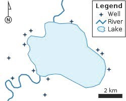

- **Formats :** Shapefile (contient les fichiers d’extension *.dbf*,*.shx*,*.sbn*, *.sbx*,*.prj*); GeoJSON;

- **Données raster :** Le modèle de données spatiales raster représente le monde avec une grille continue de cellules (souvent également appelées pixels). Ce modèle de données fait souvent référence à des grilles dites régulières, dans lesquelles chaque cellule a la même taille constante.  
  Le format le plus courant pour sauvegarder ces fichiers sont par exemple le format *GeoTIFF*.

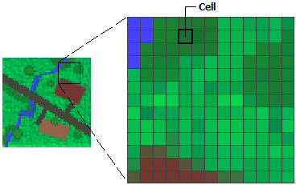

# Système de coordonnées géographiques

Les systèmes de référence de coordonnées géographiques identifient n’importe quel emplacement sur la surface de la Terre à l’aide de deux valeurs : la longitude et la latitude  
Sur R, pour créer un CRS on utilise la fonction CRS() du package sp. Par exemple :

```r
crs <- CRS("+proj=utm +datum=WGS84 +ellps=WGS84")
```

**Identification du système de coordonnées (CRS) d’un objet `sf`**  
-La fonction `st_crs` permet d’identifier le système de coordonnées d’un objet `sf`

```r
st_crs(objetspa)
```

**Modification du système de coordonnées (CRS) d’un objet sf**  
On peut modifier le « CRS » d’un objet `sf` dès lors que celui-ci est absent ou incorrect.

```r
st_crs(objetspa)=newcrs
```

Pour convertir des données d’un CRS à un autre, on peut utiliser la fonction `st_transform()`

```r
transformed_data <- st_transform(data, crs_new)
```

# Opérations sur les données non spatiales

**Passage de données non spatiales à des données de classe “Spatial”**

Nous allons utiliser dans la base de données **ACLED**

```r
acled_df <- read.csv("Data/ACLED-Western_Africa.csv")
head(acled_df, 2)
```

```
##         id      date annee                   type         pays latitude
## 1 BFO10160 30-Jun-23  2023 Strategic developments Burkina Faso  14.0400
## 2 BFO10164 30-Jun-23  2023 Strategic developments Burkina Faso  12.0299
##   longitude
## 1   -0.0300
## 2    1.7719
```

- Les packages `sp` et `sf` pour les données vectorielles
- Le package `raster` pour les rasters .

# **Classe `sp`**

- Utilisation la fonction **coordinates()** pour passer d’un objet de classe data.frame, à un objet de classe “Spatial” `sp`

```r
library(sp)
acled_sp <- acled_df
coordinates(acled_sp) <- ~longitude + latitude
class(acled_sp)
```

```
## [1] "SpatialPointsDataFrame"
## attr(,"package")
## [1] "sp"
```

- Classe des objets spatiaux:

-**SpatialPointsDataFrame**(pour les points).  
-**SpatialLinesDataFrame** (pour les objets de type ligne brisée comme les routes).  
-**SpatialPolygonsDataFrame** (pour les objets de type polygone comme les contours administratifs).

```r
str(acled_sp)
```

```
## Formal class 'SpatialPointsDataFrame' [package "sp"] with 5 slots
##   ..@ data       :'data.frame':  54138 obs. of  5 variables:
##   .. ..$ id   : chr [1:54138] "BFO10160" "BFO10164" "BFO10171" "MAA1633" ...
##   .. ..$ date : chr [1:54138] "30-Jun-23" "30-Jun-23" "30-Jun-23" "30-Jun-23" ...
##   .. ..$ annee: int [1:54138] 2023 2023 2023 2023 2023 2023 2023 2023 2023 2023 ...
##   .. ..$ type : chr [1:54138] "Strategic developments" "Strategic developments" "Explosions/Remote violence" "Protests" ...
##   .. ..$ pays : chr [1:54138] "Burkina Faso" "Burkina Faso" "Burkina Faso" "Mauritania" ...
##   ..@ coords.nrs : int [1:2] 7 6
##   ..@ coords     : num [1:54138, 1:2] -0.03 1.772 0.534 -17.038 -11.57 ...
##   .. ..- attr(*, "dimnames")=List of 2
##   .. .. ..$ : chr [1:54138] "1" "2" "3" "4" ...
##   .. .. ..$ : chr [1:2] "longitude" "latitude"
##   ..@ bbox       : num [1:2, 1:2] -25.16 2.86 14.65 25.99
##   .. ..- attr(*, "dimnames")=List of 2
##   .. .. ..$ : chr [1:2] "longitude" "latitude"
##   .. .. ..$ : chr [1:2] "min" "max"
##   ..@ proj4string:Formal class 'CRS' [package "sp"] with 1 slot
##   .. .. ..@ projargs: chr NA
```

Un objet SpatialPointsDataFrame est constitué des 5 attributs suivants :  
• **data** : le jeu de données au format data.frame,  
• **coords.nrs** : indique le numéro des colonnes indiquant les localisations géographiques dans l’objet de départ (ici acled_sp),  
• **coords** : les variables de géolocalisation,  
• **bbox** (pour “bounding box” en anglais) : une matrice qui indique les coordonnées de la fenêtre qui permet d’englober l’ensemble des objets spatiaux,  
• **proj4string** : un objet de classe CRS qui détermine le CRS utilisé pour représenter les objets spatiaux.  
Pour accéder aux différents élements qui constituent ce type d’objet, on utilise le symbole @. Par exemple, pour accéder uniquement au data.frame, on fait :

```r
head(acled_sp@data, 2)
```

```
##         id      date annee                   type         pays
## 1 BFO10160 30-Jun-23  2023 Strategic developments Burkina Faso
## 2 BFO10164 30-Jun-23  2023 Strategic developments Burkina Faso
```

```r
head(acled_sp@coords, 2)
```

```
##   longitude latitude
## 1   -0.0300  14.0400
## 2    1.7719  12.0299
```

# **Classe `sf`**

Pour transformer un objet de classe data.frame (ou alors de type “Spatial”, c’est-à-dire **SpatialPointsDataFrame**, **SpatialLinesDataFrame** ou **SpatialPolygonsDataFrame**) en objet de classe `sf`, on utilise la fonction **st_as_sf()** de la manière suivante :

```r
library(sf)
acled_sf <- st_as_sf(acled_df, coords = c("longitude", "latitude"))
class(acled_sf)
```

```
## [1] "sf"         "data.frame"
```

- Les différents types de géometries:  
  •**POINT** : un point unique,  
  • **LINESTRING** : une séquence de points reliées par des traits,  
  • **POLYGON** : une séquence de points définissant un polygone,  
  • **MULTIPOINT** : plusieurs points,  
  • **MULTILINESTRING** : plusieurs lignes,  
  • **MULTIPOLYGON** : plusieurs polygones  
  • **GEOMETRYCOLLECTION** : un mélange des géométries vues précédemment.

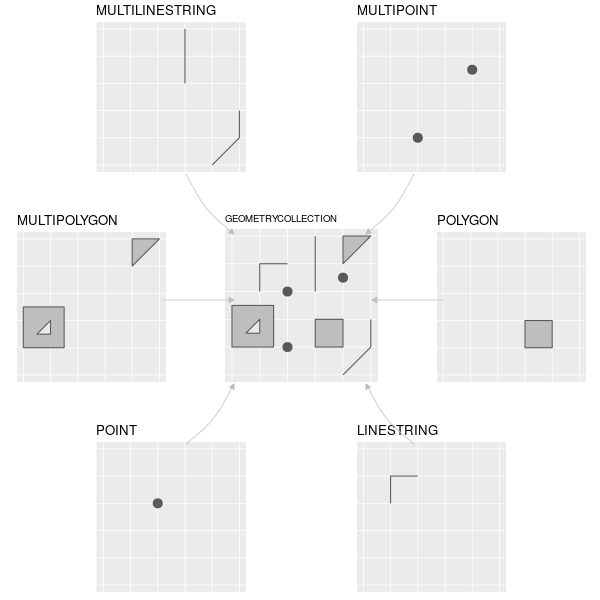

# Manipulation des données spatiaux

## Méthodes sp

-Les Méthodes de manipulation des objets sp :  
-**Objets sp**

```r
methods(class = "Spatial")
```

```
 [1] $             $<-           [             [[            [[<-
 [6] [<-           aggregate     bbox          buffer        cbind
[11] coerce        coordinates<- couldBeLonLat crop          crs<-
[16] df_spatial    dimensions    distance      ext           extent
[21] fullgrid      geometry      geometry<-    geomtype      gridded
[26] head          is.projected  isLonLat      KML           mask
[31] merge         nlayers       over          plot          polygons
[36] print         proj4string   proj4string<- raster        rebuild_CRS
[41] select        shapefile     show          spChFIDs<-    spsample
[46] spTransform   st_as_sf      st_bbox       st_crs        subset
[51] summary       tail          vect          wkt           xmax
[56] xmin          ymax          ymin          zoom
see '?methods' for accessing help and source code
```

# Méthodes sf

-Les Méthodes de manipulation des objets sf :  
- **Objets sf**

```r
methods(class = "sf")
```

```
##   [1] $<-                          [
##   [3] [[<-                         [<-
##   [5] aggregate                    anti_join
##   [7] arrange                      as.data.frame
##   [9] cbind                        coerce
##  [11] crs                          dbDataType
##  [13] dbWriteTable                 df_spatial
##  [15] distance                     distinct
##  [17] dplyr_reconstruct            duplicated
##  [19] ext                          extent
##  [21] extract                      filter
##  [23] full_join                    group_by
##  [25] group_split                  identify
##  [27] initialize                   inner_join
##  [29] left_join                    lines
```

[output cut: 44 more lines]

# Operations sur les géometries

### Package `sf`

Une question plus spécifique du point de vue de R est « pourquoi utiliser le package `sf` » ? Les raisons sont nombreuses (liées aux avantages du modèle à fonctionnalités simples) : • Lecture et écriture rapides des données  
• Performances de traçage améliorées  
• les objets `sf` peuvent être traités comme des trames de données dans la plupart des opérations  
• les noms de fonctions `sf` sont relativement cohérents et intuitifs (ils commencent tous par st_)  
• Les fonctions `sf` peuvent être combinées avec l’ |>opérateur et fonctionnent bien avec la collection Tidyverse de packages R.

# Operations

**Union, intersection, différence, etc. sur les géométries**

Avec la norme sf, les fonctions qui peuvent être utiles pour travailler sur les géométries sont :  
• `st_intersection(A, B)` : l’intersection des géométries A et B  
• `st_union(A, B)` : l’union des géométries A et B  
• `st_difference(A, B)` : la géométrie de A auquel on enlève la géométrie de B  
• `st_convex_hull(x)` : détermine une enveloppe convexe de x  
• `st_area(x)`: détermine l’aire de x  
• `st_buffer(x)`: détermine un tampon de x.

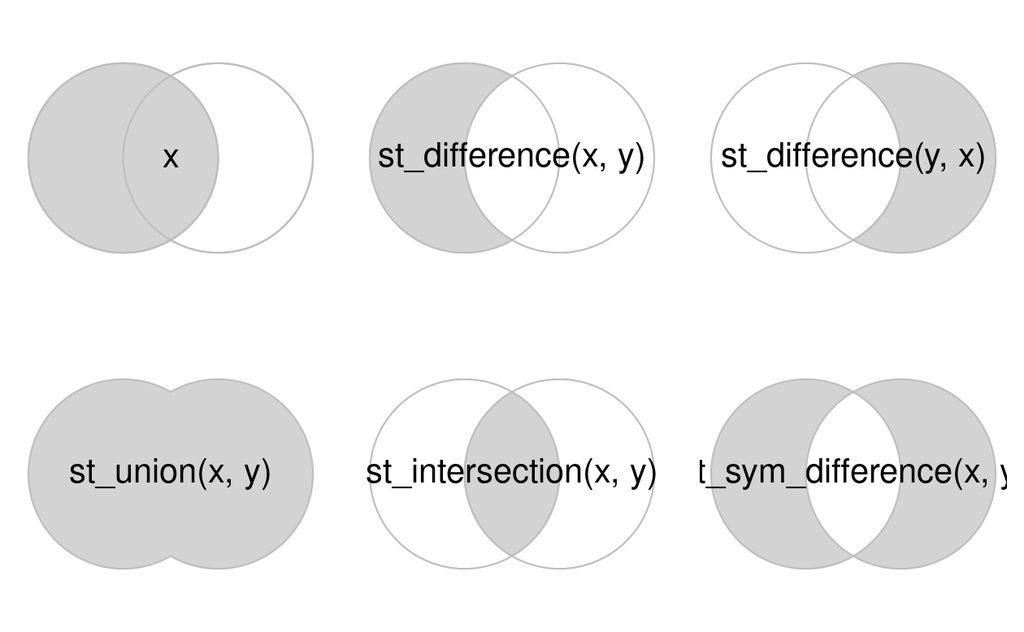

# *Union simple*

```r
sen <- suppressMessages(st_read("Data/gadm41_SEN_shp/gadm41_SEN_2.shp"))
```

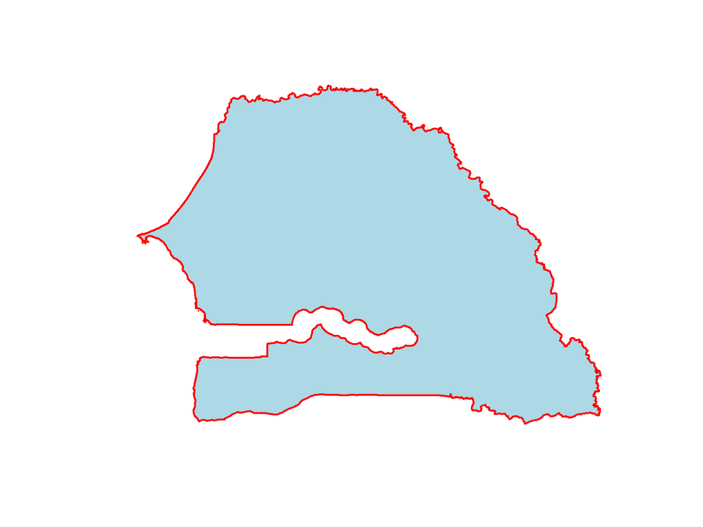

```r
sen_u <- st_union(sen)
plot(st_geometry(sen_u), col="lightblue")
plot(st_geometry(sen_u), add=T, lwd=2, border = "red")
```

# *Zone tampon*

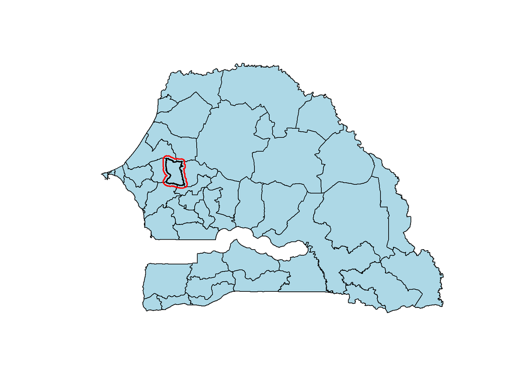

```r
Diourbel <- sen[sen$NAME_2 == "Diourbel", ]
Diourbel_b <- st_buffer(x = Diourbel, dist = 5000)
plot(st_geometry(sen), col = "lightblue")
plot(st_geometry(Diourbel), add = TRUE, lwd = 2)
plot(st_geometry(Diourbel_b), add = TRUE, lwd = 2, border = "red")
```

# *Intersection de polygones*

Pour ce faire on crée un polygone

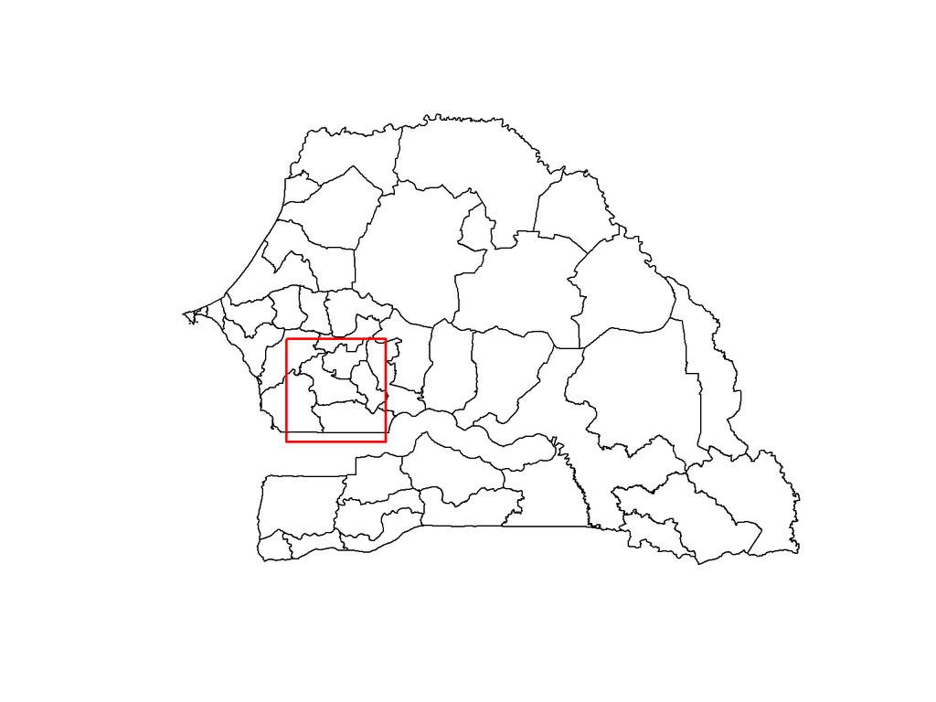

```r
m <- rbind(c(-16.5, 13.5), c(-16.5, 14.5), c(-15.5, 14.5),
           c(-15.5, 13.5), c(-16.5, 13.5))
polygone <- st_sf(st_sfc(st_polygon(list(m))), crs = st_crs(sen))
plot(st_geometry(sen))
plot(polygone, border = "red", lwd = 2, add = TRUE)
```

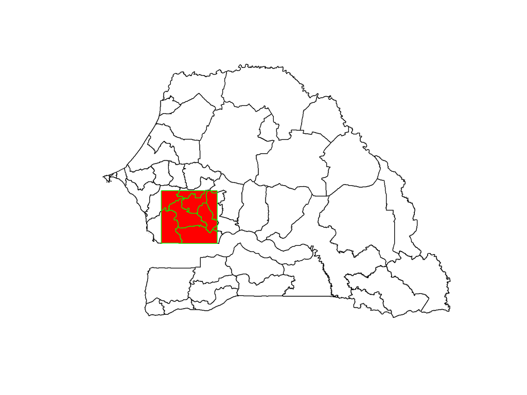

```r
inter <- st_intersection(x = sen, y = polygone)
plot(st_geometry(sen))
plot(st_geometry(inter), col = "red", border = "green", add = TRUE)
```

# Cartes statiques

[figure not shown]

# Avec `ggplot 2`

## **Les cartes choroplèthe**

Le premier exemple que nous allons pouvoir voir, c’est une carte choroplèthe, càd en aplat de couleur, adaptée à la représentation d’indicateurs intensifs (%, densité…).

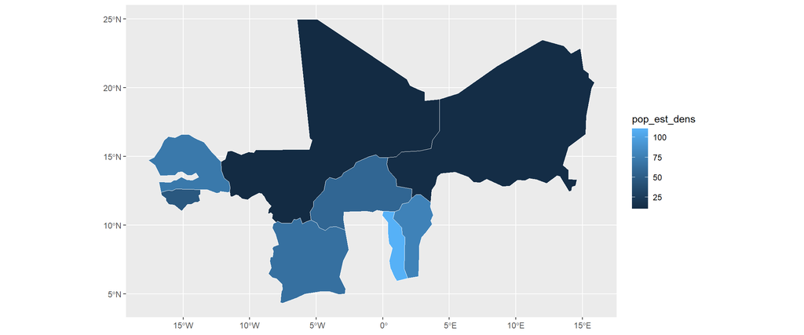

```r
library(ggplot2)
ggplot(data = uemoa_sf) +
  geom_sf(mapping = aes(fill = pop_est_dens), color = "white")
```

## **Les cartes à ronds proportionnels**

- Utilisation de La fonction `stat_sf_coordinates()` permet d’extraire les coordonnées d’un objet ‘sf’ avant de produire le calque.

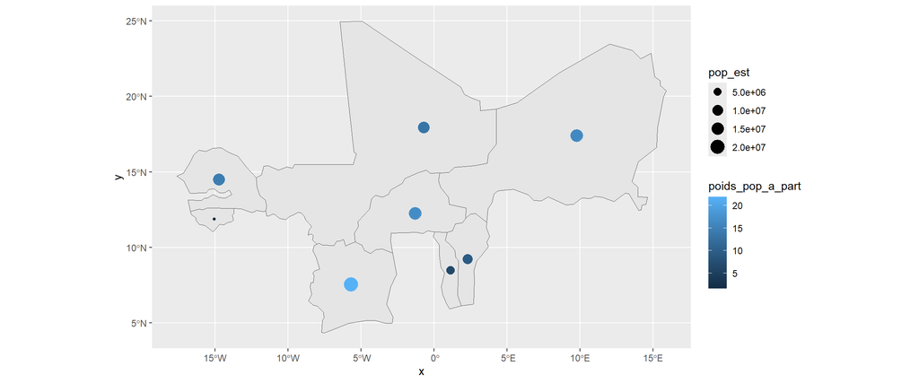

```r
library(ggplot2)
carte_ronds_prop <- ggplot(data = uemoa_sf) +
  geom_sf() +
  stat_sf_coordinates(mapping = aes(size = pop_est, color = poids_pop_a_part))

carte_ronds_prop
```

### **Ajout du titre ,legende,flêche pole nord…**

- *Utilisation des fonction* :  
  -`labs()` pour les labels  
  -`title` pour le tire, `subtitle` pour le sous-titre et `caption` le bas de page .  
  -`guide_xx()` et `guides()` permettent de modifier finement la légende.  
  -`annotation_scale()` et `annotation_north_arrow()` pour ajouter l’ échelle et la flèche du nord.

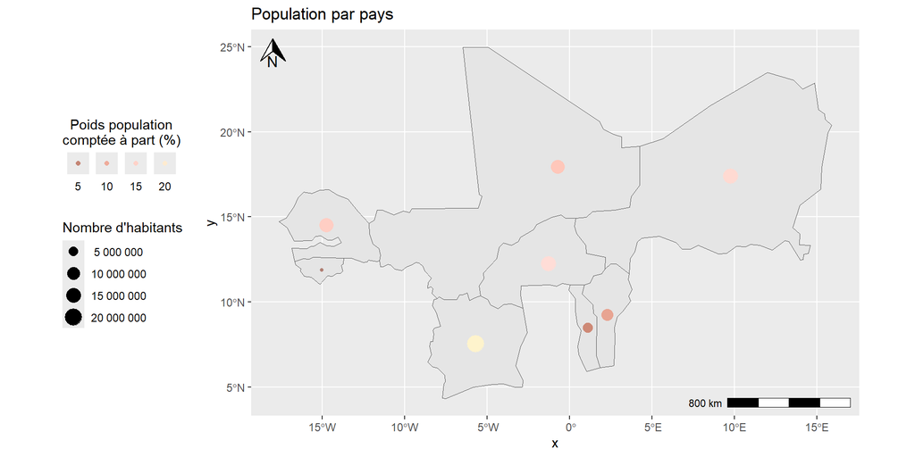

# Avec `mf_map`

La fonction `mf_map()` est la fonction centrale du package `mapsf` . Elle permet de réaliser la plupart des représentations usuelles en cartographie. Ces arguments principaux sont :  
• **x**, un objet sf ;  
• **var**, le nom de la variable à représenter ;  
• **type**, le type de représentation.  
Utilisée sans précision de type, la fonction `mf_map()` affche simplement les couches spatiales.

**Carte de symboles proportionnels**

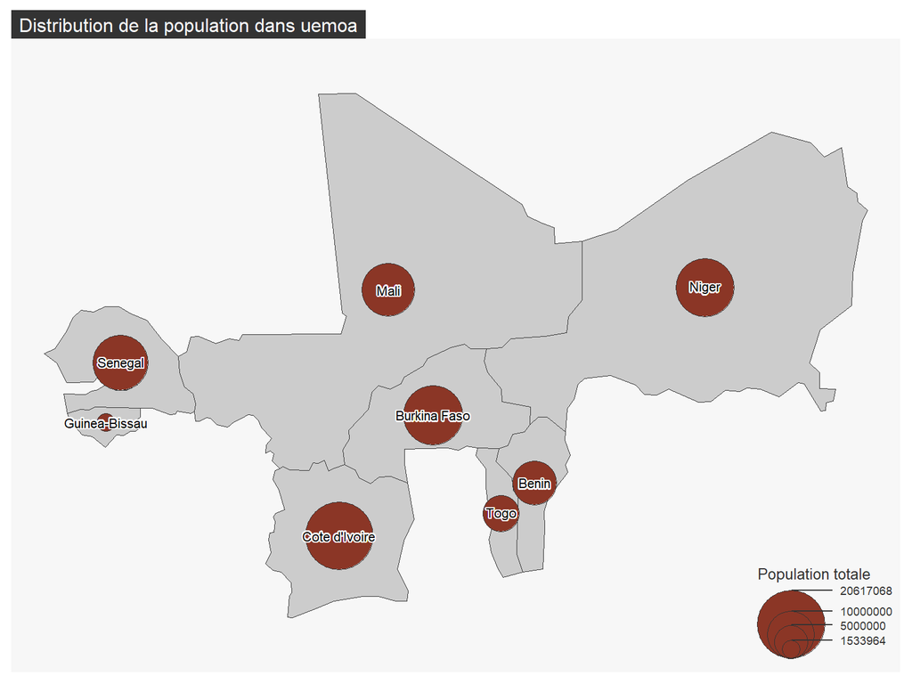

```r
# uemoa
mf_map(x = uemoa_sf)
# Symboles proportionnels
mf_map(
x = uemoa_sf,
var = "pop_est",
type = "prop",
leg_title = "Population totale"
)
mf_label(
x = uemoa_sf,
var = "name",
col= "black",
halo = TRUE,
overlap = FALSE,
lines = FALSE
)
# Titre
mf_title("Distribution de la population dans uemoa")
```

**Les cartes choroplèthe**

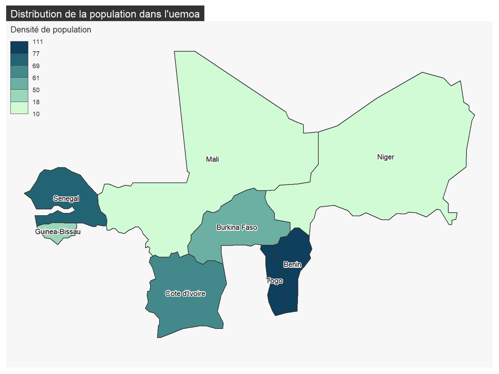

```r
mf_map(x = uemoa_sf,
var = "pop_est_dens",
type = "choro",
breaks = "quantile",
nbreaks = 6,
pal = "Dark Mint",
lwd = 1,
leg_title = "Densité de population",
leg_val_rnd = 0,
leg_pos = "topleft"

)
mf_label(
x = uemoa_sf,
var = "name",
col= "black",
halo = TRUE,
overlap = FALSE,
lines = FALSE
)
mf_title("Distribution de la population dans l'uemoa")
```

# Avec `tmap`

La syntaxe de `tmap` est similaire à celle de ggplot2. Cela inclut une séparation stricte entre les données et l’esthétique. Au début, `tm_shape()` est transmis un ensemble de données, suivi d’un ou plusieurs niveaux qui définissent le type d’affichage. Les exemples sont `tm_fill()`et `tm_dots()`pour tracer des données sous forme de polygones ou de points.

**Exemple de graphique avec `tmap`**

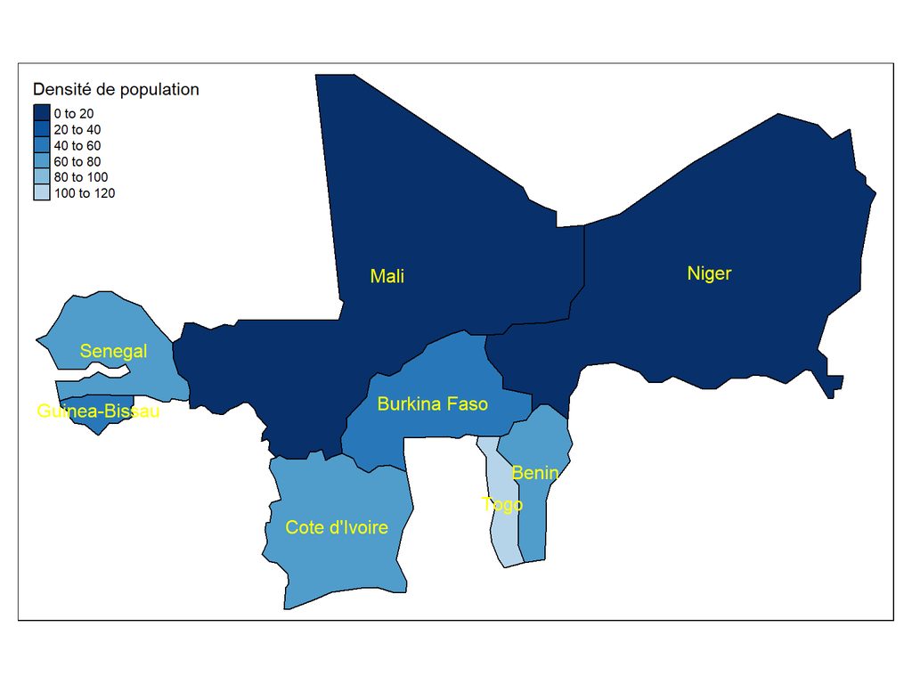

```r
library(tmap)
# plot
tm_shape(uemoa_sf) +
  tm_polygons("pop_est_dens", palette = "-Blues",
    title = "Densité de population", contrast = 0.7, border.col = "black", id = "name") +
  tm_text("name", col = "yellow")
```

# Cartes dynamiques

La représentation de données spatiales se veut de plus en plus interactive, et quoi de mieux qu’une carte pour illustrer son propos lorsque l’on souhaite transmettre une information géographique ?

# tmap

Nous pouvons egalemet faire des cartes dynamiques avec le package `tmap`

```r
tmap_mode("view")
```

```
## tmap mode set to interactive viewing
```

```r
tm_shape(uemoa_sf) +
  tm_polygons("pop_est_dens", palette = "-Blues",
    title = "Densité de population", contrast = 0.7, border.col = "black", id = "name",
    popup.vars="pop_est") +
  tm_text("name", col = "yellow")
```

[interactive chart not shown]

```r
tmap_mode("plot")
```

```
## tmap mode set to plotting
```

# leaflet

Nous allons utiliser ici le package *leaflet*

[output not shown]

```r
# Créer une palette de couleurs en fonction du nombre d'attaques
palette_couleurs <- colorQuantile("YlOrRd", domain = uemoa_sf$pop_est)

carte <- leaflet(data = uemoa_sf) %>%
  addTiles() %>%
  addPolygons(
    color = "#fff",   # Couleur des bordures
    weight = 1,          # Épaisseur des bordures
    fillOpacity = 0.6,   # Opacité du remplissage
    fillColor = ~palette_couleurs(uemoa_sf$pop_est),
    label = paste(uemoa_sf[['name']], ": ", uemoa_sf$pop_est)
  ) %>%
  addLegend(
    title = "Population des pays de l'uemoa",
    pal = palette_couleurs, values = uemoa_sf$pop_est
  ) %>%
  addMiniMap(width = 150, height = 150) %>% # minimap
  addMeasure(
    position = "bottomleft",
    primaryLengthUnit = "meters",
    primaryAreaUnit = "sqmeters",
    activeColor = "#3D535D",
    completedColor = "#7D4479") %>%# mesure de la distance entre les points
# add a layers control
  addLayersControl(
    baseGroups = c(
      "OpenStreetMap", "Stamen.Toner",
      "Stamen.Terrain", "Esri.WorldStreetMap",
      "Wikimedia", "CartoDB.Positron", "Esri.WorldImagery"
    ),
    # position it on the topleft
    position = "topright"
  )%>%
  addDrawToolbar()%>%
  addMeasurePathToolbar(options = measurePathOptions(imperial = FALSE,
                                                     minPixelDistance = 100,
                                                     showDistances = FALSE,
                                                     showOnHover = TRUE))
carte
```

[interactive chart not shown]

## Tableau resumant les caracteristiques de chaque pays

```r
leaflet(uemoa_sf, height = '400px') %>%
  addProviderTiles(providers$CartoDB.Positron) %>%
  addPolygons(color = ~palette_couleurs(uemoa_sf$pop_est), fillOpacity = 0.7,
              popup = ~leafpop::popupTable(uemoa_sf,                            #<<
                                           zcol = c("name", "area", "pop_est"), #<<
                                           row.numbers = FALSE, feature.id = FALSE)) #<<
```

[interactive chart not shown]

# ggiraph

*ggiraph* est un package qui permet de créer des graphes interactifs, notamment via l’ajout de tooltips, d’animations, et d’actions JavaScript. Il dispose notamment d’une fonction permettant de réaliser des cartes interactives.

```r
g <- ggplot(africa) +
  geom_polygon_interactive(
    color='black',
    aes(long, lat, group=group, fill=internet.usage.2021,
        tooltip=sprintf("%s<br/>%s",ISO_A3,internet.usage.2021))) +
 ggthemes::theme_map() +
  colormap::scale_fill_colormap(
    colormap=colormap::colormaps$copper, reverse = T) +
  labs(title=' Usage Internet en Afrique en 2021',
       caption='Source: World Bank Open Data.')

girafe(code=print(g))
```

[interactive chart not shown]

# Rasters

## création raster

```r
resolution <- 10/111
base_raster2 <- raster(base_pays, res = resolution)
#rasterize convertit une couche vectorielle en raster
base_raster3 <-rasterize(base_acled, base_raster2, field = "id", fun="count",background =0,
mask=F, update=T, updateValue="all", filename="", na.rm=TRUE)
base_raster3 <- mask(base_raster3, base_pays)
```

# affichage

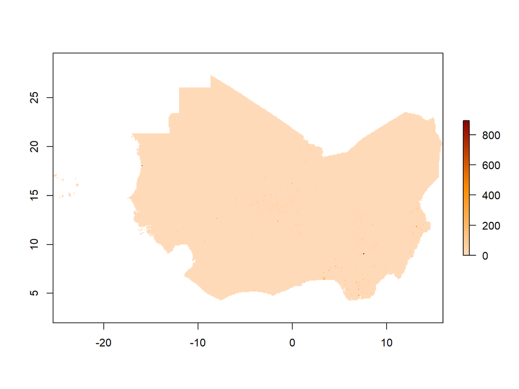

```r
palette_couleurs <- colorRampPalette(c("peachpuff", "darkorange", "darkred"))
plot(base_raster3, col= palette_couleurs(100))
```

# Representation

```r
library(leaflet)
# Créer une carte leaflet
map <- leaflet() %>% addTiles()%>%
    addProviderTiles("OpenStreetMap.Mapnik") %>%
    addRasterImage(base_raster3, opacity = 0.7,project =FALSE )

# Afficher la carte interactive avec la légende

map
```

[interactive chart not shown]

# Lecture d’un raster

```r
alt_sen <- elevation_30s(country = "SEN", path = tempdir())
```

Representation

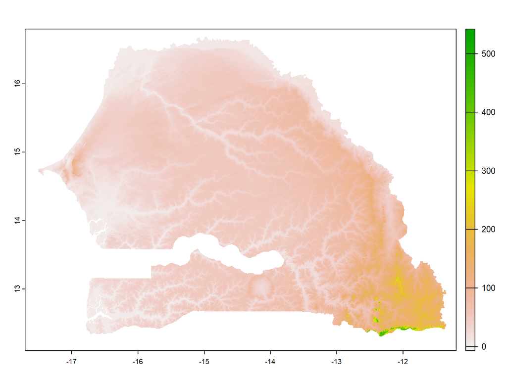

```r
plot(alt_sen)
```

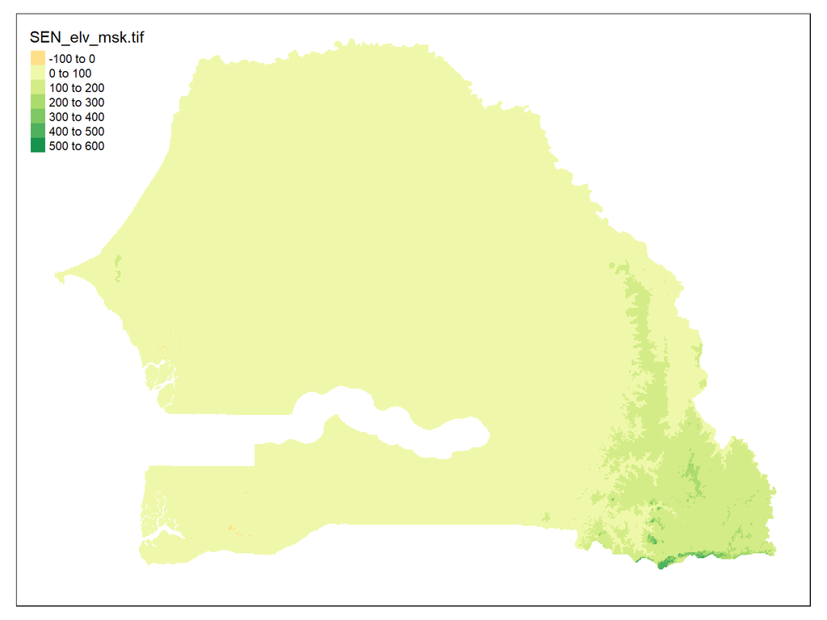

```r
tm_shape(alt_sen) + tm_raster()
```

# BIBLIOGRAPHIE ET WEBOGRAPHIE

1-Nicolas Casajus, *ANALYSES SPATIALES SOUS R*  
2-Timothée Giraud,Hugues Pecout, *Cartographie avec R*  
3-Nicolas Roelandt, *Données géospatiales et cartographie avec R*  
4-Kim Antunez, *Données géographiques et cartographie sous R :Manipulation de données communales en historique et réalisation de cartes*  
5- Nicolas Lambert & Ronan Ysebaert, *FAIRE DES CARTES AVEC R : La frontière États-Unis - Mexique*  
6- Philippe Marchand, *Introduction au traitement des données géospatiales avec R*  
7-https://r-charts.com/spatial/interactive-maps-leaflet/, *Interactive maps with leaflet in R*  
8-https://r.geocompx.org/foreword-1st-edition, *Geocomputation with R*